# Project: Investigate a TMDB Dataset

- Introduction
- Data Wrangling
- Exploratory Data Analysis
- Conclusions

## Introduction

### In this project, The Movie Database dataset was chosen in attempt to explore different attributes of the data to find different types of relations an try to analyze those relations. The set is consists of over 10,000 data records of movies from TMDB archive.

> **TMDB.ORG** is a crowd-sourced movie information database used by many film-related consoles, sites and apps, such as XBMC, MythTV and Plex. Dozens of media managers, mobile apps and social sites make use of its API.  
> TMDb lists over 80,000 films at time of writing, which is considerably fewer than IMDb. While not as complete as IMDb, it holds extensive information for most popular/ Hollywood films.

### Research Questions:

1. Does the audience prefare to sit through a long feature (over 90 minutes) or they prefare shorter runtimes?
2. Among all the movie genres in the sample data, which movie genre is the most popular?

```python
# Use this cell to set up import statements for all of the packages that you
#   plan to use.

# Remember to include a 'magic word' so that your visualizations are plotted
#   inline with the notebook. See this page for more:
#   http://ipython.readthedocs.io/en/stable/interactive/magics.html
import pandas as pd
import numpy as np
import matplotlib.pyplot as plt
import matplotlib
%matplotlib inline
```

## Data Wrangling

> **Tip**: In this section of the report, you will load in the data, check for cleanliness, and then trim and clean your dataset for analysis. Make sure that you document your steps carefully and justify your cleaning decisions.

### Overview of the data:

#### In oreder to get more familiar with the provided data, this is a very breif illusturation of the columns data.

#### This will help later to determine what type of data we will need to answer our questions.

id: Unique identifier for each entry.</li>

imdb_id: Corresponding IMDB.COM id.</li>

popularity: The calculated popularity of the entry movie.</li>

budget: Esitmated budget of the movie.</li>

revenue: The revenue shows the movie profit.</li>

original_title: Movie name</li>

cast: The cast of the movie. In our data, it mentioned the actors with the starring roles.</li>

homepage: Link to the movie website.</li>

director: The movie director.</li>

tagline: A quote or sentence that sums up the movie idea. Used to advertise the movie.</li>

keywords: Key and important words that describe the movie story and ideas.</li>

overview: Review of the movie.</li>

runtime: The duration of the movie in minutes.</li>

genres: Movie category and classification.</li>

production_companies: Producers of the movie. It is usually individual or a collaboration between differnt studios.</li>

release_date: Release date of the movie ':)</li>

vote_count: Viewers' vote for the movie.</li>

vote_average: The average of the given votes from viewers</li>

release_year: Year the movie got released in theaters.</li>

budget_adj: Adjustble budget in 2010, to account for inflation of the currency and production cost.</li>

revenue_adj: Adjustble revenue in 2010.</li>

### General Properties

```python
# Load your data and print out a few lines. Perform operations to inspect data
#   types and look for instances of missing or possibly errant data.
movies_df = pd.read_csv('tmdb-movies.csv')
movies_df.head(1)
```

|  | id | imdb_id | popularity | budget | revenue | original_title | cast | homepage | director | tagline | ... | overview | runtime | genres | production_companies | release_date | vote_count | vote_average | release_year | budget_adj | revenue_adj |
| --- | --- | --- | --- | --- | --- | --- | --- | --- | --- | --- | --- | --- | --- | --- | --- | --- | --- | --- | --- | --- | --- |
| 0 | 135397 | tt0369610 | 32.985763 | 150000000 | 1513528810 | Jurassic World | Chris Pratt\|Bryce Dallas Howard\|Irrfan Khan\|Vi... | http://www.jurassicworld.com/ | Colin Trevorrow | The park is open. | ... | Twenty-two years after the events of Jurassic ... | 124 | Action\|Adventure\|Science Fiction\|Thriller | Universal Studios\|Amblin Entertainment\|Legenda... | 6/9/15 | 5562 | 6.5 | 2015 | 1.379999e+08 | 1.392446e+09 |

1 rows × 21 columns

> **Tip**: You should *not* perform too many operations in each cell. Create cells freely to explore your data. One option that you can take with this project is to do a lot of explorations in an initial notebook. These don't have to be organized, but make sure you use enough comments to understand the purpose of each code cell. Then, after you're done with your analysis, create a duplicate notebook where you will trim the excess and organize your steps so that you have a flowing, cohesive report.

> **Tip**: Make sure that you keep your reader informed on the steps that you are taking in your investigation. Follow every code cell, or every set of related code cells, with a markdown cell to describe to the reader what was found in the preceding cell(s). Try to make it so that the reader can then understand what they will be seeing in the following cell(s).

### Data Cleaning:

Drop Uncessary Data for This Task.

```python
# After discussing the structure of the data and any problems that need to be
#   cleaned, perform those cleaning steps in the second part of this section.

movies_df.drop (['imdb_id', 'budget', 'revenue', 'cast', 'director', 'keywords', 'homepage', 'tagline', 'overview', 'production_companies'], axis =1, inplace=True)
```

**Following columns were dropped:**

*imdb_id:* There is already a unique identifier for the data with much more intuitive and direct label.

*budget & revenue:* In order to have a more accurit answers for the financials, I opte to take the adjestable rate, which will unite all the values to match the cost and profits in 2010.

*cast & director:* The people behind the movie won't serve our analysis. Although it can be used to determine the most successful cast, actor, actress, and movie maker. It just not the route that will be taken today.

*keywords:* Again it can be helpful for other analysis, however, not this one.

*homepage:* Won't be used in this analysis.

*tagline:* Wont' be used in this analysis.

*overview:* The movie breif won't add to this analysis.

*production_companies:* Won't be used in this analysis.

For the purpose of analysis that is been attempted to obtain in this project these data are not of much interest. Which could be true or not. Each analyst has its own way to find the desired results. For some other questions the dropped data could be essential.  
The main purpose of dropping is to have a more manageable dataset to work with instead of having data that won't be used.

```python
movies_df.head(1)
```

|  | id | popularity | original_title | runtime | genres | release_date | vote_count | vote_average | release_year | budget_adj | revenue_adj |
| --- | --- | --- | --- | --- | --- | --- | --- | --- | --- | --- | --- |
| 0 | 135397 | 32.985763 | Jurassic World | 124 | Action\|Adventure\|Science Fiction\|Thriller | 6/9/15 | 5562 | 6.5 | 2015 | 1.379999e+08 | 1.392446e+09 |

```python
movies_df.info()
```

```
<class 'pandas.core.frame.DataFrame'>
RangeIndex: 10866 entries, 0 to 10865
Data columns (total 11 columns):
id                10866 non-null int64
popularity        10866 non-null float64
original_title    10866 non-null object
runtime           10866 non-null int64
genres            10843 non-null object
release_date      10866 non-null object
vote_count        10866 non-null int64
vote_average      10866 non-null float64
release_year      10866 non-null int64
budget_adj        10866 non-null float64
revenue_adj       10866 non-null float64
dtypes: float64(4), int64(4), object(3)
memory usage: 933.9+ KB
```

```python
movies_df.shape
```

```
(10866, 11)
```

**As per the information obtained by the previous commands, we know that we have 10866 enteries in our dataset.**

```python
movies_df.describe()
```

|  | id | popularity | runtime | vote_count | vote_average | release_year | budget_adj | revenue_adj |
| --- | --- | --- | --- | --- | --- | --- | --- | --- |
| count | 10866.000000 | 10866.000000 | 10866.000000 | 10866.000000 | 10866.000000 | 10866.000000 | 1.086600e+04 | 1.086600e+04 |
| mean | 66064.177434 | 0.646441 | 102.070863 | 217.389748 | 5.974922 | 2001.322658 | 1.755104e+07 | 5.136436e+07 |
| std | 92130.136561 | 1.000185 | 31.381405 | 575.619058 | 0.935142 | 12.812941 | 3.430616e+07 | 1.446325e+08 |
| min | 5.000000 | 0.000065 | 0.000000 | 10.000000 | 1.500000 | 1960.000000 | 0.000000e+00 | 0.000000e+00 |
| 25% | 10596.250000 | 0.207583 | 90.000000 | 17.000000 | 5.400000 | 1995.000000 | 0.000000e+00 | 0.000000e+00 |
| 50% | 20669.000000 | 0.383856 | 99.000000 | 38.000000 | 6.000000 | 2006.000000 | 0.000000e+00 | 0.000000e+00 |
| 75% | 75610.000000 | 0.713817 | 111.000000 | 145.750000 | 6.600000 | 2011.000000 | 2.085325e+07 | 3.369710e+07 |
| max | 417859.000000 | 32.985763 | 900.000000 | 9767.000000 | 9.200000 | 2015.000000 | 4.250000e+08 | 2.827124e+09 |

Check and Drop Duplicate Data.

```python
movies_df.duplicated().sum()
```

```
1
```

```python
#Let's take a look at which mmovie entry has been duplicated.
#This need to be checked through themovie id.

movies_df[movies_df.duplicated(['id'])]
```

|  | id | popularity | original_title | runtime | genres | release_date | vote_count | vote_average | release_year | budget_adj | revenue_adj |
| --- | --- | --- | --- | --- | --- | --- | --- | --- | --- | --- | --- |
| 2090 | 42194 | 0.59643 | TEKKEN | 92 | Crime\|Drama\|Action\|Thriller\|Science Fiction | 3/20/10 | 110 | 5.0 | 2010 | 30000000.0 | 967000.0 |

```python
movies_df.drop_duplicates(inplace = True)
```

```python
movies_df.duplicated().sum()
```

```
0
```

**Only one duplicated value found, which is not that bad considering the amount of data. However, for the purpose of project demonstration the data need to be all unique.**

```python
movies_df.nunique()
```

```
id                10865
popularity        10814
original_title    10571
runtime             247
genres             2039
release_date       5909
vote_count         1289
vote_average         72
release_year         56
budget_adj         2614
revenue_adj        4840
dtype: int64
```

Check and Drop Null Values in the Data.

```python
movies_df.isnull().sum()
```

```
id                 0
popularity         0
original_title     0
runtime            0
genres            23
release_date       0
vote_count         0
vote_average       0
release_year       0
budget_adj         0
revenue_adj        0
dtype: int64
```

There are several *NULL* values in "genres" data

```python
movies_df.dropna(subset = ['genres'], inplace = True)
movies_df.isnull().sum()
```

```
id                0
popularity        0
original_title    0
runtime           0
genres            0
release_date      0
vote_count        0
vote_average      0
release_year      0
budget_adj        0
revenue_adj       0
dtype: int64
```

```python
movies_df.info()
```

```
<class 'pandas.core.frame.DataFrame'>
Int64Index: 10842 entries, 0 to 10865
Data columns (total 11 columns):
id                10842 non-null int64
popularity        10842 non-null float64
original_title    10842 non-null object
runtime           10842 non-null int64
genres            10842 non-null object
release_date      10842 non-null object
vote_count        10842 non-null int64
vote_average      10842 non-null float64
release_year      10842 non-null int64
budget_adj        10842 non-null float64
revenue_adj       10842 non-null float64
dtypes: float64(4), int64(4), object(3)
memory usage: 1016.4+ KB
```

Check and Fill Zero Cells.

**In order to clean-up the data we must make sure that there are no 0 values in the dataset.**

```python
#Check for zeros and identify the columns
movies_df.describe()
```

|  | id | popularity | runtime | vote_count | vote_average | release_year | budget_adj | revenue_adj |
| --- | --- | --- | --- | --- | --- | --- | --- | --- |
| count | 10842.000000 | 10842.000000 | 10842.000000 | 10842.000000 | 10842.000000 | 10842.000000 | 1.084200e+04 | 1.084200e+04 |
| mean | 65870.675521 | 0.647461 | 102.138443 | 217.823649 | 5.974064 | 2001.314794 | 1.758712e+07 | 5.147797e+07 |
| std | 91981.355752 | 1.001032 | 31.294612 | 576.180993 | 0.934257 | 12.813617 | 3.433437e+07 | 1.447723e+08 |
| min | 5.000000 | 0.000065 | 0.000000 | 10.000000 | 1.500000 | 1960.000000 | 0.000000e+00 | 0.000000e+00 |
| 25% | 10589.250000 | 0.208210 | 90.000000 | 17.000000 | 5.400000 | 1995.000000 | 0.000000e+00 | 0.000000e+00 |
| 50% | 20557.000000 | 0.384532 | 99.000000 | 38.000000 | 6.000000 | 2006.000000 | 0.000000e+00 | 0.000000e+00 |
| 75% | 75186.000000 | 0.715393 | 111.000000 | 146.000000 | 6.600000 | 2011.000000 | 2.092507e+07 | 3.387838e+07 |
| max | 417859.000000 | 32.985763 | 900.000000 | 9767.000000 | 9.200000 | 2015.000000 | 4.250000e+08 | 2.827124e+09 |

**Runtime contains some zero values, in addition to the adjustible budget and revenue. So, let's replace the empty data with the avrage of each value.**

```python
movies_df['runtime'] = movies_df['runtime'].replace(0, movies_df['runtime'].mean())

movies_df['budget_adj']=movies_df['budget_adj'].replace(0,movies_df['budget_adj'].mean())

movies_df['revenue_adj'] = movies_df['revenue_adj'].replace(0, movies_df['revenue_adj'].mean())


# Let's check the shape of the data after the above adjustments.
movies_df.describe()
```

|  | id | popularity | runtime | vote_count | vote_average | release_year | budget_adj | revenue_adj |
| --- | --- | --- | --- | --- | --- | --- | --- | --- |
| count | 10842.000000 | 10842.000000 | 10842.000000 | 10842.000000 | 10842.000000 | 10842.000000 | 1.084200e+04 | 1.084200e+04 |
| mean | 65870.675521 | 0.647461 | 102.421062 | 217.823649 | 5.974064 | 2001.314794 | 2.679108e+07 | 7.993283e+07 |
| std | 91981.355752 | 1.001032 | 30.828622 | 576.180993 | 0.934257 | 12.813617 | 3.053264e+07 | 1.366907e+08 |
| min | 5.000000 | 0.000065 | 2.000000 | 10.000000 | 1.500000 | 1960.000000 | 9.210911e-01 | 2.370705e+00 |
| 25% | 10589.250000 | 0.208210 | 90.000000 | 17.000000 | 5.400000 | 1995.000000 | 1.758712e+07 | 5.147797e+07 |
| 50% | 20557.000000 | 0.384532 | 99.000000 | 38.000000 | 6.000000 | 2006.000000 | 1.758712e+07 | 5.147797e+07 |
| 75% | 75186.000000 | 0.715393 | 111.000000 | 146.000000 | 6.600000 | 2011.000000 | 2.092507e+07 | 5.147797e+07 |
| max | 417859.000000 | 32.985763 | 900.000000 | 9767.000000 | 9.200000 | 2015.000000 | 4.250000e+08 | 2.827124e+09 |

Check and Adjust Data Types.

```python
movies_df.dtypes
```

```
id                  int64
popularity        float64
original_title     object
runtime           float64
genres             object
release_date       object
vote_count          int64
vote_average      float64
release_year        int64
budget_adj        float64
revenue_adj       float64
dtype: object
```

```python
movies_df.info()
```

```
<class 'pandas.core.frame.DataFrame'>
Int64Index: 10842 entries, 0 to 10865
Data columns (total 11 columns):
id                10842 non-null int64
popularity        10842 non-null float64
original_title    10842 non-null object
runtime           10842 non-null float64
genres            10842 non-null object
release_date      10842 non-null object
vote_count        10842 non-null int64
vote_average      10842 non-null float64
release_year      10842 non-null int64
budget_adj        10842 non-null float64
revenue_adj       10842 non-null float64
dtypes: float64(5), int64(3), object(3)
memory usage: 1016.4+ KB
```

```python
#In order to have hte ability to use release_date vlaue, it need to be changed.

movies_df['release_date'] = pd.to_datetime(movies_df['release_date'])
```

```python
movies_df.dtypes
```

```
id                         int64
popularity               float64
original_title            object
runtime                  float64
genres                    object
release_date      datetime64[ns]
vote_count                 int64
vote_average             float64
release_year               int64
budget_adj               float64
revenue_adj              float64
dtype: object
```

## Exploratory Data Analysis

> **Tip**: Now that you've trimmed and cleaned your data, you're ready to move on to exploration. Compute statistics and create visualizations with the goal of addressing the research questions that you posed in the Introduction section. It is recommended that you be systematic with your approach. Look at one variable at a time, and then follow it up by looking at relationships between variables.

### Visualization

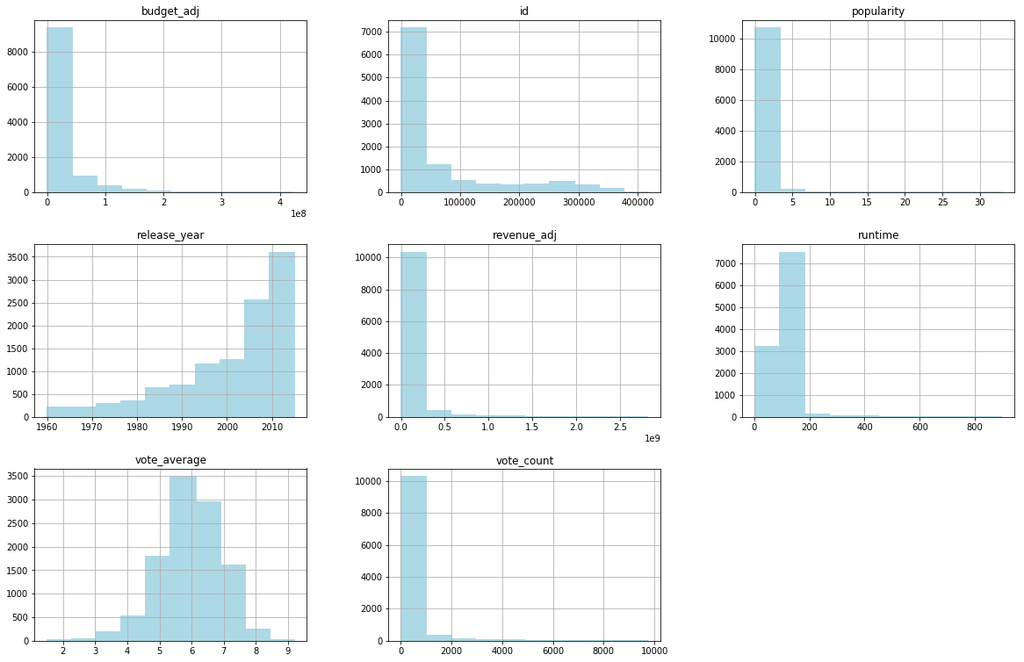

```python
colors = ['red', 'tan', 'lime']
movies_df.hist(histtype='step',stacked=True,fill=True,figsize=(20,13), edgecolor= 'lightblue', color = 'lightblue', linewidth=2);
```

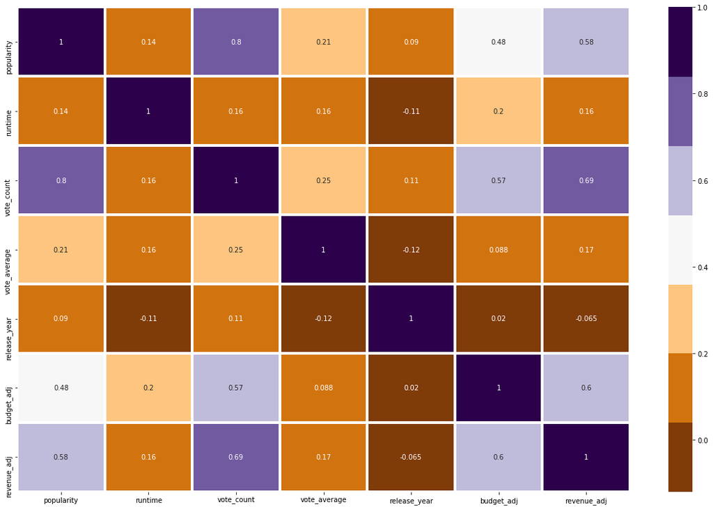

```python
plt.figure(figsize = (20,13));
data = movies_df[movies_df.dtypes[movies_df.dtypes != 'object'].index[1:]].corr()
sns.heatmap(data, cmap=plt.get_cmap("PuOr", 7),annot = True, linewidth=3);
```

### Research Question 1:

### Best Movie Runtime.

```
We will multiple drawings to get to what is the sweet runtime spot for movie goers.
```

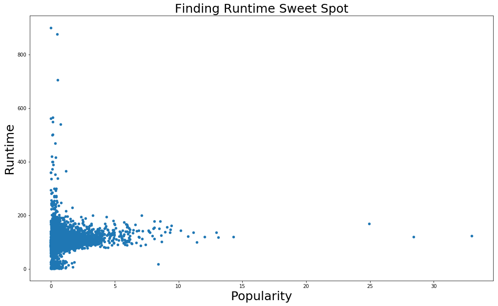

```python
movies_df.plot(x='popularity', y='runtime', kind='scatter',figsize=(17,10))
plt.title('Finding Runtime Sweet Spot', fontsize=25)
plt.xlabel('Popularity', fontsize=25)
plt.ylabel('Runtime', fontsize=25);
```

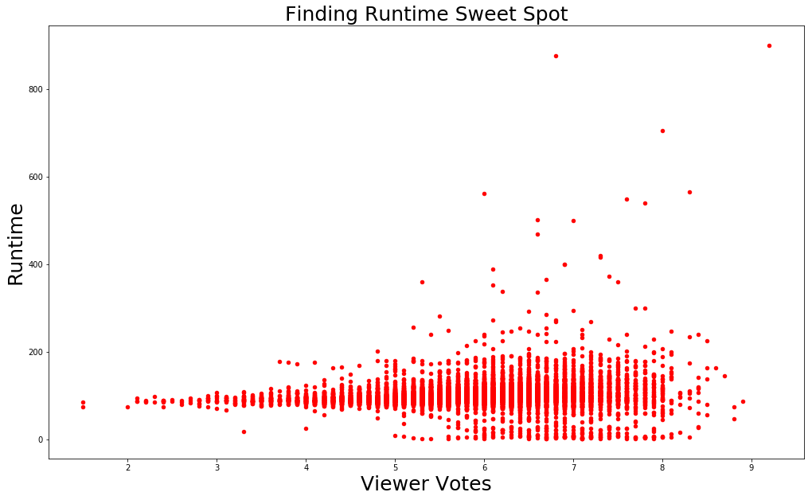

```python
movies_df.plot(x='vote_average', y='runtime', kind='scatter', color='r',figsize=(17,10))
plt.title('Finding Runtime Sweet Spot', fontsize=25)
plt.xlabel('Viewer Votes', fontsize=25)
plt.ylabel('Runtime', fontsize=25);
```

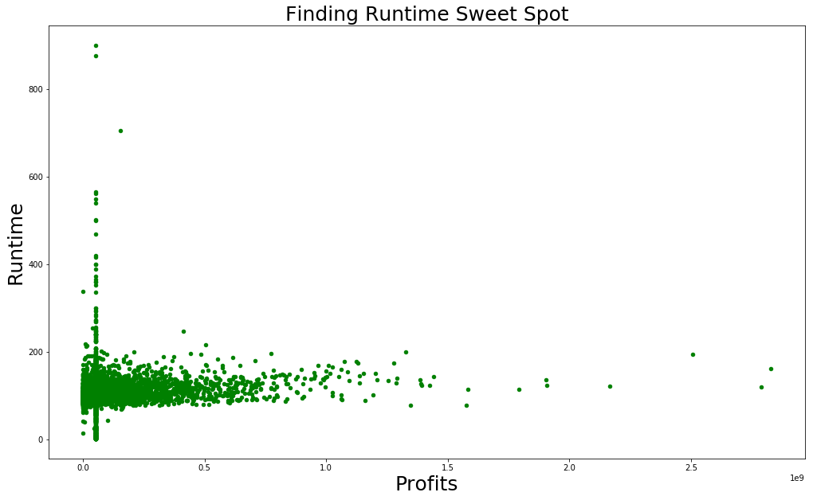

```python
movies_df.plot(x='revenue_adj', y='runtime', kind='scatter', color='g',figsize=(17,10))
plt.title('Finding Runtime Sweet Spot', fontsize=25)
plt.xlabel('Profits', fontsize=25)
plt.ylabel('Runtime', fontsize=25);
```

```
We tested the movie runtime against three elements (Revenue, Number of votes, and Popularity of the movie).
Although the votes produced much cleaner and readable graph, the other showed interesting resaults.
It seems that, as per this dataset, the faveorable runtime is around 90 - 120 minutes.
```

#### Issues with previous results

As showed above there were I had to find the best pairing data types to answer the best runtime question. At first, it made sense to test the runtime against the popularity of a movie with the audiance, however, as demonstirated above, scattered graph was not clear enough to give us a decisive answer.  
After investigating the data, it is clear that due to the nature of the value of the popularity record, which is float, it caused a lot of "noises" in the scatter graph as many vlaues were very close and not definit enough. Would've been more suitable if the numbers integers for percision.  
The same goes to the revenue data although it is more understandable to have float numbers when we count the profit a movie made.

### Research Question 2:

### Best Genre.

```
In order to find the most popular movie genre, we will have to seperate each of the genres into it is own column so that we can get to our desired results.
```

```python
def separate(data):
    return data.str[0:].str.split('|', expand = True)

genres = separate(movies_df['genres'])
genres['id'] = movies_df['id']
```

```python
def melt(df, col_name):
    return pd.melt(df, id_vars = 'id',value_name = col_name).drop(labels = 'variable',axis = 1)
genres = melt(genres, 'genres')
```

```
After cleaning up the cluster.
Let's expolre what are most requested genre.
```

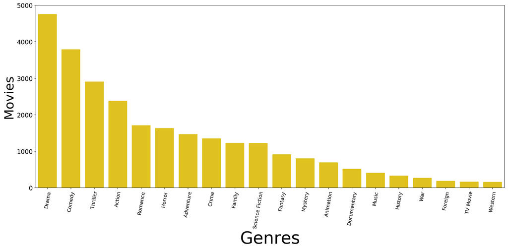

```python
plt.figure(figsize = (20,8), dpi = 150);
sns.countplot(genres['genres'],order = genres['genres'].value_counts().index, color='gold');
plt.ylabel("Movies",fontsize = 30);
plt.xlabel("Genres", fontsize = 40);
plt.xticks(rotation = 80, fontsize = 12);
plt.yticks(fontsize = 15);
```

```
It seems that most demanded genres are Drama, then Comedy, then Thrillers and Action, which all scores above 2000.
```

#### Issues with previous data

Some of the categories I wish would have been combined to have more clear classifications. For example there is Thriller, Action, Crime, and Horror catigories as genres which all somewhat can be worked to one or two genres.  
Also, the "TV Movie" does not sound much as a genres and more as another type of medium of which viewers can view movies. So I believe it should've not be included under "genres" and be just a movie, regardless if it had a theatrical release, TV movie, or straight-to-DVD/BR type of movies. In my opinion, this affects the accuracy of the results.  
Another issue was that in order to investigate best genre, at first I though of using the popularity data, however, due to the nature of float type it made it difficult to obtain the desired results and eventually decided to count the number of movies made for each genre, which I believe it showed pretty complete result.

### Resources:

https://www.themoviedb.org/  
https://pandas.pydata.org/pandas-docs/stable/reference/  
https://pandas.pydata.org/pandas-docs/stable/reference/frame.html  
https://stackoverflow.com/questions/42116091/pandas-dataframe-drop-valueerror-labels-id-not-contained-in-axis  
https://pbpython.com/pandas_dtypes.html  
https://stackoverflow.com/questions/49290266/python-matplotlib-histogram-specify-different-colours-for-different-bars  
https://matplotlib.org/gallery/images_contours_and_fields/image_annotated_heatmap.html  
https://www.kaggle.com/abdullahsahin/step-by-step-pandas-tutorial-for-beginner  
https://chrisalbon.com/python/data_wrangling/pandas_with_seaborn/  
https://matplotlib.org/gallery/statistics/histogram_multihist.html  
https://www.geeksforgeeks.org/python-pandas-split-strings-into-two-list-columns-using-str-split/